# PROJECT--INCOME-QUALIFICATION

```python
#Import Data Analysis Libraries:
import numpy as np
import pandas as pd

#Import Plotting Libraries:
import matplotlib.pyplot as plt
%matplotlib inline
import seaborn as sns

#Import Data Preprocessing Libraries:
from sklearn.preprocessing import MinMaxScaler
from sklearn.preprocessing import Imputer

#Import Model Libraries:
from sklearn.model_selection import train_test_split
from sklearn.ensemble import RandomForestClassifier

#Import Error Metrics Libraries:
from sklearn.metrics import classification_report
from sklearn.metrics import precision_score
from sklearn.metrics import recall_score
from sklearn.metrics import f1_score
from sklearn.metrics import accuracy_score
from sklearn.metrics import confusion_matrix
```

```python
#Set background style for the graphs:
sns.set_style('whitegrid')
```

```python
#Load training Dataset:
income_train_df = pd.read_csv(r'C:\Simplilearn-Machine-Learning\8th-June-Batch-9AM--1PM--Amit--DONE\PROJECT-FOLDER\Machine-Learning--Projects-master\Projects\Projects for Submission\Project 2 - Income Qualification\Dataset for the project\train.csv')
```

```python
#Review the dataset:
income_train_df.head(7)
```

|  | Id | v2a1 | hacdor | rooms | hacapo | v14a | refrig | v18q | v18q1 | r4h1 | ... | SQBescolari | SQBage | SQBhogar_total | SQBedjefe | SQBhogar_nin | SQBovercrowding | SQBdependency | SQBmeaned | agesq | Target |
| --- | --- | --- | --- | --- | --- | --- | --- | --- | --- | --- | --- | --- | --- | --- | --- | --- | --- | --- | --- | --- | --- |
| 0 | ID_279628684 | 190000.0 | 0 | 3 | 0 | 1 | 1 | 0 | NaN | 0 | ... | 100 | 1849 | 1 | 100 | 0 | 1.000000 | 0.0 | 100.0 | 1849 | 4 |
| 1 | ID_f29eb3ddd | 135000.0 | 0 | 4 | 0 | 1 | 1 | 1 | 1.0 | 0 | ... | 144 | 4489 | 1 | 144 | 0 | 1.000000 | 64.0 | 144.0 | 4489 | 4 |
| 2 | ID_68de51c94 | NaN | 0 | 8 | 0 | 1 | 1 | 0 | NaN | 0 | ... | 121 | 8464 | 1 | 0 | 0 | 0.250000 | 64.0 | 121.0 | 8464 | 4 |
| 3 | ID_d671db89c | 180000.0 | 0 | 5 | 0 | 1 | 1 | 1 | 1.0 | 0 | ... | 81 | 289 | 16 | 121 | 4 | 1.777778 | 1.0 | 121.0 | 289 | 4 |
| 4 | ID_d56d6f5f5 | 180000.0 | 0 | 5 | 0 | 1 | 1 | 1 | 1.0 | 0 | ... | 121 | 1369 | 16 | 121 | 4 | 1.777778 | 1.0 | 121.0 | 1369 | 4 |
| 5 | ID_ec05b1a7b | 180000.0 | 0 | 5 | 0 | 1 | 1 | 1 | 1.0 | 0 | ... | 121 | 1444 | 16 | 121 | 4 | 1.777778 | 1.0 | 121.0 | 1444 | 4 |
| 6 | ID_e9e0c1100 | 180000.0 | 0 | 5 | 0 | 1 | 1 | 1 | 1.0 | 0 | ... | 4 | 64 | 16 | 121 | 4 | 1.777778 | 1.0 | 121.0 | 64 | 4 |

7 rows × 143 columns

```python
#View information about dataset:
income_train_df.info()
```

```
<class 'pandas.core.frame.DataFrame'>
RangeIndex: 9557 entries, 0 to 9556
Columns: 143 entries, Id to Target
dtypes: float64(8), int64(130), object(5)
memory usage: 10.4+ MB
```

- By observing the above information we can say that there are **138 columns[130(int64)+8(float64)]** are of right data type means appropriate for model input and only 5 are of type object.So, we need to preprocess those 5 columns and convert them into numerical format.
- [NOTE: WE NEED TO PERFORM THIS PREPROCESSING STEP BECAUSE OUR PREDICTION MODEL ONLY ACCEPTS DATA IN NUMERICAL FORMAT NOT IN CATEGORICAL FORMAT.]

```python
#Check the shape of the Training dataset:
income_train_df.shape
```

```
(9557, 143)
```

- **9557**: Observations
- **143** : Features

```python
#Check if any missing values in Target column:
income_train_df['Target'].isnull().any()
```

```
False
```

```python
#Check unique values and their count in Target column:
income_train_df['Target'].value_counts()
```

```
4    5996
2    1597
3    1209
1     755
Name: Target, dtype: int64
```

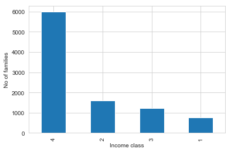

```python
#Visualize the target column:
income_train_df['Target'].value_counts().plot(kind="bar")
plt.xlabel("Income class")
plt.ylabel("No of families")
plt.show()
```

```python
#Describe the dataset(Get Descriptive Statistics):
income_train_df.describe()
```

|  | v2a1 | hacdor | rooms | hacapo | v14a | refrig | v18q | v18q1 | r4h1 | r4h2 | ... | SQBescolari | SQBage | SQBhogar_total | SQBedjefe | SQBhogar_nin | SQBovercrowding | SQBdependency | SQBmeaned | agesq | Target |
| --- | --- | --- | --- | --- | --- | --- | --- | --- | --- | --- | --- | --- | --- | --- | --- | --- | --- | --- | --- | --- | --- |
| count | 2.697000e+03 | 9557.000000 | 9557.000000 | 9557.000000 | 9557.000000 | 9557.000000 | 9557.000000 | 2215.000000 | 9557.000000 | 9557.000000 | ... | 9557.000000 | 9557.000000 | 9557.000000 | 9557.000000 | 9557.000000 | 9557.000000 | 9557.000000 | 9552.000000 | 9557.000000 | 9557.000000 |
| mean | 1.652316e+05 | 0.038087 | 4.955530 | 0.023648 | 0.994768 | 0.957623 | 0.231767 | 1.404063 | 0.385895 | 1.559171 | ... | 74.222769 | 1643.774302 | 19.132887 | 53.500262 | 3.844826 | 3.249485 | 3.900409 | 102.588867 | 1643.774302 | 3.302292 |
| std | 1.504571e+05 | 0.191417 | 1.468381 | 0.151957 | 0.072145 | 0.201459 | 0.421983 | 0.763131 | 0.680779 | 1.036574 | ... | 76.777549 | 1741.197050 | 18.751395 | 78.445804 | 6.946296 | 4.129547 | 12.511831 | 93.516890 | 1741.197050 | 1.009565 |
| min | 0.000000e+00 | 0.000000 | 1.000000 | 0.000000 | 0.000000 | 0.000000 | 0.000000 | 1.000000 | 0.000000 | 0.000000 | ... | 0.000000 | 0.000000 | 1.000000 | 0.000000 | 0.000000 | 0.040000 | 0.000000 | 0.000000 | 0.000000 | 1.000000 |
| 25% | 8.000000e+04 | 0.000000 | 4.000000 | 0.000000 | 1.000000 | 1.000000 | 0.000000 | 1.000000 | 0.000000 | 1.000000 | ... | 16.000000 | 289.000000 | 9.000000 | 0.000000 | 0.000000 | 1.000000 | 0.111111 | 36.000000 | 289.000000 | 3.000000 |
| 50% | 1.300000e+05 | 0.000000 | 5.000000 | 0.000000 | 1.000000 | 1.000000 | 0.000000 | 1.000000 | 0.000000 | 1.000000 | ... | 36.000000 | 961.000000 | 16.000000 | 36.000000 | 1.000000 | 2.250000 | 0.444444 | 81.000000 | 961.000000 | 4.000000 |
| 75% | 2.000000e+05 | 0.000000 | 6.000000 | 0.000000 | 1.000000 | 1.000000 | 0.000000 | 2.000000 | 1.000000 | 2.000000 | ... | 121.000000 | 2601.000000 | 25.000000 | 81.000000 | 4.000000 | 4.000000 | 1.777778 | 134.560010 | 2601.000000 | 4.000000 |
| max | 2.353477e+06 | 1.000000 | 11.000000 | 1.000000 | 1.000000 | 1.000000 | 1.000000 | 6.000000 | 5.000000 | 8.000000 | ... | 441.000000 | 9409.000000 | 169.000000 | 441.000000 | 81.000000 | 36.000000 | 64.000000 | 1369.000000 | 9409.000000 | 4.000000 |

8 rows × 138 columns

```python
#Drop columns Id and idhogar as it contains so much varying data:
income_train_df.drop(['Id','idhogar'],axis=1,inplace=True)
```

```python
#Chack shape of the dataframe:
income_train_df.shape
```

```
(9557, 141)
```

```python
import warnings
warnings.filterwarnings(action='ignore')
```

```python
income_train_df[['v2a1']].info()
```

```
<class 'pandas.core.frame.DataFrame'>
RangeIndex: 9557 entries, 0 to 9556
Data columns (total 1 columns):
v2a1    2697 non-null float64
dtypes: float64(1)
memory usage: 74.7 KB
```

```python
income_train_df['v2a1'].isnull().sum()
```

```
6860
```

```python
#We can see that this column has huge number of missing values(around 6860).Ideally we drop column in this situation.
#But Will decide whether to drop it or not based on its correlation with output variable:
```

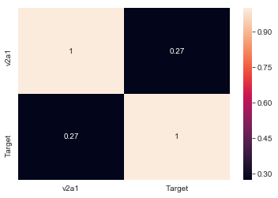

```python
sns.heatmap(income_train_df[['v2a1','Target']].corr(),annot=True)
plt.show()
```

```python
#By observing the above plot we can see that the correlation of v2a1 with output is Positive but not much strong.
```

- We can see that column v2a1 has 6860 missing values or NaN values.So we are going to use Imputer class to fill up these values.
- But we are going to impute values based on the number of rooms.As column v2a1 is specifying monthly rent payment and by intuation we know that rent payment is depend on size of the house and size of the house is based on number of rooms.

```python
income_train_df.groupby("rooms").v2a1.mean()
```

```
rooms
1      63344.814815
2      93637.534247
3     114242.625850
4     120205.598203
5     154373.894611
6     215407.449782
7     287232.601399
8     411316.901639
9     605221.619048
10    570540.000000
11              NaN
Name: v2a1, dtype: float64
```

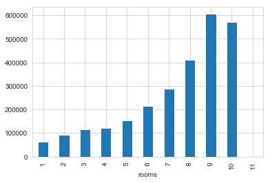

```python
income_train_df.groupby("rooms").v2a1.mean().plot(kind='bar')
plt.show()
```

- By observing the above graph we can say that there is a huge variance in column monthly rent payment based on number of rooms.So,we are going to write a custom function to impute missing values in column v2a1 based on the number of rooms.But if we see the graph again we can clearly notice that there is some bias after number of rooms 9.For number of rooms 10 we see that the rent payment amount is decreased.

```python
income_train_df.groupby("Target").v2a1.mean()
```

```
Target
1     84806.464052
2     97015.166172
3    102618.093333
4    193589.258521
Name: v2a1, dtype: float64
```

```python
def rent_payment(cols):
    rent_amount = cols[0]
    no_of_rooms = cols[1]

    if pd.isnull(rent_amount):
        if no_of_rooms == 1:
            return 63344.814815
        elif no_of_rooms == 2:
            return 93637.534247
        elif no_of_rooms == 3:
            return 114242.625850
        elif no_of_rooms == 4:
            return 120205.598203
        elif no_of_rooms == 5:
            return 154373.894611
        elif no_of_rooms == 6:
            return 215407.449782
        elif no_of_rooms == 7:
            return 287232.601399
        elif no_of_rooms == 8:
            return 411316.901639
        elif no_of_rooms == 9:
            return 605221.619048
        elif no_of_rooms == 10:
            return 570540.000000
        elif no_of_rooms == 11:
            return 645475.066875
        else:
            np.nan
```

```python
income_train_df['v2a1'] = income_train_df[['v2a1','rooms']].apply(rent_payment,axis=1)
```

```python
income_train_df['v2a1'].isnull().sum()
```

```
2697
```

- Still there are some missing values but now the count is much smallar than previous.So,we will fill up those missing values using **'mean' value** of the column.

```python
income_train_df['v2a1'].mean()
```

```
182848.53926665484
```

```python
#Create Instance of the Imputer class:
imputer_v2a1 = Imputer(missing_values='NaN',strategy='mean',axis=0)
imputer_v2a1
```

```
Imputer(axis=0, copy=True, missing_values='NaN', strategy='mean', verbose=0)
```

```python
income_train_df['v2a1'] = imputer_v2a1.fit_transform(income_train_df[['v2a1']])
```

```python
#Get the info of the column:
income_train_df[['v2a1']].info()
```

```
<class 'pandas.core.frame.DataFrame'>
RangeIndex: 9557 entries, 0 to 9556
Data columns (total 1 columns):
v2a1    9557 non-null float64
dtypes: float64(1)
memory usage: 74.7 KB
```

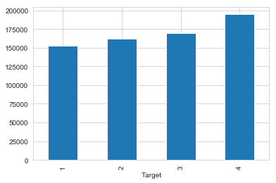

```python
#Check how rent payment can varies based on Income Qualification:
income_train_df.groupby("Target").v2a1.mean().plot(kind="bar")
plt.show()
```

```python
income_train_df[['v18q1']].info()
```

```
<class 'pandas.core.frame.DataFrame'>
RangeIndex: 9557 entries, 0 to 9556
Data columns (total 1 columns):
v18q1    2215 non-null float64
dtypes: float64(1)
memory usage: 74.7 KB
```

```python
#Check for null values in v18q1 column:
income_train_df['v18q1'].isnull().sum()
```

```
7342
```

```python
income_train_df['v18q1'].value_counts()
```

```
1.0    1586
2.0     444
3.0     129
4.0      37
5.0      13
6.0       6
Name: v18q1, dtype: int64
```

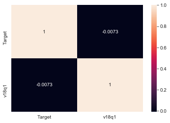

```python
sns.heatmap(income_train_df[['Target','v18q1']].corr(),annot=True)
plt.show()
```

```python
#As we can see that the variable v18q1 is categorial in nature.So,we are using 'mode' strategy to fill up those missing values:
imputer_v18q1 = Imputer(missing_values='NaN',strategy='most_frequent')
imputer_v18q1
```

```
Imputer(axis=0, copy=True, missing_values='NaN', strategy='most_frequent',
    verbose=0)
```

```python
income_train_df['v18q1'] = imputer_v18q1.fit_transform(income_train_df[['v18q1']])
```

```python
#Check info of the column:
income_train_df[['v18q1']].info()
```

```
<class 'pandas.core.frame.DataFrame'>
RangeIndex: 9557 entries, 0 to 9556
Data columns (total 1 columns):
v18q1    9557 non-null float64
dtypes: float64(1)
memory usage: 74.7 KB
```

```python
income_train_df[['rez_esc']].info()
```

```
<class 'pandas.core.frame.DataFrame'>
RangeIndex: 9557 entries, 0 to 9556
Data columns (total 1 columns):
rez_esc    1629 non-null float64
dtypes: float64(1)
memory usage: 74.7 KB
```

```python
income_train_df['rez_esc'].isnull().sum()
```

```
7928
```

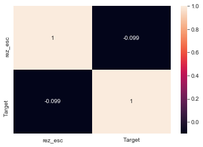

```python
sns.heatmap(income_train_df[['rez_esc','Target']].corr(),annot=True)
plt.show()
```

```python
income_train_df['rez_esc'].value_counts()
```

```
0.0    1211
1.0     227
2.0      98
3.0      55
4.0      29
5.0       9
Name: rez_esc, dtype: int64
```

```python
imputer_rez_esc = Imputer(missing_values='NaN',strategy='most_frequent',axis=0)
imputer_rez_esc
```

```
Imputer(axis=0, copy=True, missing_values='NaN', strategy='most_frequent',
    verbose=0)
```

```python
income_train_df['rez_esc'] = imputer_rez_esc.fit_transform(income_train_df[['rez_esc']])
```

```python
#Check for missing values:
income_train_df['rez_esc'].isnull().sum()
```

```
0
```

```python
#Check info of the column:
income_train_df[['rez_esc']].info()
```

```
<class 'pandas.core.frame.DataFrame'>
RangeIndex: 9557 entries, 0 to 9556
Data columns (total 1 columns):
rez_esc    9557 non-null float64
dtypes: float64(1)
memory usage: 74.7 KB
```

```python
#Drop rows with null values:
income_train_df.dropna(axis=0,how='any',inplace=True)
```

```python
income_train_df.reset_index(drop=True,inplace=True)
```

```python
income_train_df.info()
```

```
<class 'pandas.core.frame.DataFrame'>
RangeIndex: 9552 entries, 0 to 9551
Columns: 141 entries, v2a1 to Target
dtypes: float64(8), int64(130), object(3)
memory usage: 10.3+ MB
```

### Treatment for Categorical Columns

```python
#Converting Catorial data into numeriacal:
income_train_df['dependency'] = np.where(income_train_df['dependency']=='yes',1,income_train_df['dependency'])
```

```python
income_train_df['dependency'] = np.where(income_train_df['dependency']=='no',0,income_train_df['dependency'])
```

```python
income_train_df['edjefe'] = np.where(income_train_df['edjefe']=='yes',1,income_train_df['edjefe'])
```

```python
income_train_df['edjefe'] = np.where(income_train_df['edjefe']=='no',0,income_train_df['edjefe'])
```

```python
income_train_df['edjefa'] = np.where(income_train_df['edjefa']=='yes',1,income_train_df['edjefa'])
```

```python
income_train_df['edjefa'] = np.where(income_train_df['edjefa']=='no',0,income_train_df['edjefa'])
```

```python
income_train_df.info()
```

```
<class 'pandas.core.frame.DataFrame'>
RangeIndex: 9552 entries, 0 to 9551
Columns: 141 entries, v2a1 to Target
dtypes: float64(8), int64(130), object(3)
memory usage: 10.3+ MB
```

```python
#Check Shape of the Dataframe:
income_train_df.shape
```

```
(9552, 141)
```

### Changing dtype of the categorial columns:

```python
income_train_df['dependency'] = income_train_df['dependency'].astype('float')
```

```python
income_train_df['edjefe'] = income_train_df['edjefe'].astype('float')
```

```python
income_train_df['edjefa'] = income_train_df['edjefa'].astype('float')
```

```python
#Check info of the
income_train_df.info()
```

```
<class 'pandas.core.frame.DataFrame'>
RangeIndex: 9552 entries, 0 to 9551
Columns: 141 entries, v2a1 to Target
dtypes: float64(11), int64(130)
memory usage: 10.3 MB
```

```python
#Separate features:
X = income_train_df.iloc[:,:140].values
```

```python
type(X)
```

```
numpy.ndarray
```

```python
len(X)
```

```
9552
```

```python
X.ndim
```

```
2
```

```python
#Separate out the Target:
y = income_train_df.iloc[:,140].values
```

```python
len(y)
```

```
9552
```

```python
type(y)
```

```
numpy.ndarray
```

```python
y.ndim
```

```
1
```

- If we observed the columns in the dataset,the data inside the columns is not on Standard scale.And if we feed such kind of data to the model then our model will become skewed model(depending on the stronger column).So,to avoid this problem we are going to Normalize our data so that it fits on Standard Scale.
- For this,we are going to use **Min-Max Scalar.**

```python
#Create Instance of the Scalar:
min_max_sclr = MinMaxScaler()
```

```python
#Fit and transform the data:
X_train_norm =  min_max_sclr.fit_transform(X)
```

```python
type(X_train_norm)
```

```
numpy.ndarray
```

```python
X_train_norm.shape
```

```
(9552, 140)
```

```python
#Check the dataframe:
X_train_norm_df = pd.DataFrame(data=X_train_norm,columns=income_train_df.columns[:140])
```

```python
#Check the Normalized dataframe:
X_train_norm_df.head()
```

|  | v2a1 | hacdor | rooms | hacapo | v14a | refrig | v18q | v18q1 | r4h1 | r4h2 | ... | age | SQBescolari | SQBage | SQBhogar_total | SQBedjefe | SQBhogar_nin | SQBovercrowding | SQBdependency | SQBmeaned | agesq |
| --- | --- | --- | --- | --- | --- | --- | --- | --- | --- | --- | --- | --- | --- | --- | --- | --- | --- | --- | --- | --- | --- |
| 0 | 0.205287 | 0.0 | 0.2 | 0.0 | 1.0 | 1.0 | 0.0 | 0.0 | 0.0 | 0.125 | ... | 0.443299 | 0.226757 | 0.196514 | 0.000000 | 0.226757 | 0.000000 | 0.026087 | 0.000000 | 0.073046 | 0.196514 |
| 1 | 0.205287 | 0.0 | 0.3 | 0.0 | 1.0 | 1.0 | 1.0 | 0.0 | 0.0 | 0.125 | ... | 0.690722 | 0.326531 | 0.477096 | 0.000000 | 0.326531 | 0.000000 | 0.026087 | 1.000000 | 0.105186 | 0.477096 |
| 2 | 0.597756 | 0.0 | 0.7 | 0.0 | 1.0 | 1.0 | 0.0 | 0.0 | 0.0 | 0.000 | ... | 0.948454 | 0.274376 | 0.899564 | 0.000000 | 0.000000 | 0.000000 | 0.005217 | 1.000000 | 0.088386 | 0.899564 |
| 3 | 0.205287 | 0.0 | 0.4 | 0.0 | 1.0 | 1.0 | 1.0 | 0.0 | 0.0 | 0.250 | ... | 0.175258 | 0.183673 | 0.030715 | 0.089286 | 0.274376 | 0.049383 | 0.047729 | 0.015625 | 0.088386 | 0.030715 |
| 4 | 0.205287 | 0.0 | 0.4 | 0.0 | 1.0 | 1.0 | 1.0 | 0.0 | 0.0 | 0.250 | ... | 0.381443 | 0.274376 | 0.145499 | 0.089286 | 0.274376 | 0.049383 | 0.047729 | 0.015625 | 0.088386 | 0.145499 |

5 rows × 140 columns

```python
#Check info of the normalized dataframe:
X_train_norm_df.info()
```

```
<class 'pandas.core.frame.DataFrame'>
RangeIndex: 9552 entries, 0 to 9551
Columns: 140 entries, v2a1 to agesq
dtypes: float64(140)
memory usage: 10.2 MB
```

```python
y[:90]
```

```
array([4, 4, 4, 4, 4, 4, 4, 4, 4, 4, 4, 4, 4, 4, 4, 4, 4, 4, 4, 4, 4, 4,
       4, 4, 4, 4, 4, 4, 4, 4, 4, 4, 4, 4, 4, 4, 4, 4, 4, 4, 4, 4, 4, 4,
       4, 4, 4, 4, 4, 4, 2, 2, 2, 2, 4, 4, 4, 4, 2, 4, 4, 4, 4, 4, 2, 4,
       4, 4, 4, 4, 4, 4, 4, 4, 4, 4, 4, 4, 4, 4, 4, 4, 4, 4, 4, 4, 4, 4,
       4, 4], dtype=int64)
```

```python
y.shape
```

```
(9552,)
```

### BUILDING MODEL WITHOUT FEATURE ENGINNERING(PCA):

```python
#Split the Dataset into train and test:
X_train,X_test,y_train,y_test = train_test_split(X_train_norm,y,test_size=.3,random_state=22)
```

```python
print('X_train:',X_train.shape)
print('X_test:',X_test.shape)
print('y_train:',y_train.shape)
print('y_test:',y_test.shape)
```

```
X_train: (6686, 140)
X_test: (2866, 140)
y_train: (6686,)
y_test: (2866,)
```

```python
#Create an Instance of the Random Forrest Classifier with default 'criterian=gini':
random_forrest_gini = RandomForestClassifier()
random_forrest_gini
```

```
RandomForestClassifier(bootstrap=True, class_weight=None, criterion='gini',
            max_depth=None, max_features='auto', max_leaf_nodes=None,
            min_impurity_decrease=0.0, min_impurity_split=None,
            min_samples_leaf=1, min_samples_split=2,
            min_weight_fraction_leaf=0.0, n_estimators='warn', n_jobs=None,
            oob_score=False, random_state=None, verbose=0,
            warm_start=False)
```

```python
#Fit the data:
random_forrest_gini.fit(X_train,y_train)
```

```
RandomForestClassifier(bootstrap=True, class_weight=None, criterion='gini',
            max_depth=None, max_features='auto', max_leaf_nodes=None,
            min_impurity_decrease=0.0, min_impurity_split=None,
            min_samples_leaf=1, min_samples_split=2,
            min_weight_fraction_leaf=0.0, n_estimators=10, n_jobs=None,
            oob_score=False, random_state=None, verbose=0,
            warm_start=False)
```

```python
#Predict on test dataset:
y_predict = random_forrest_gini.predict(X_test)
```

```python
#Check Accuracy score:
accuracy_with_gini = accuracy_score(y_test,y_predict)
```

```python
#Accuracy:
print("Accuracy with criterian gini:",accuracy_with_gini)
```

```
Accuracy with criterian gini: 0.8907885554780182
```

```python
print(classification_report(y_test,y_predict))
```

```
              precision    recall  f1-score   support

           1       0.90      0.68      0.77       246
           2       0.84      0.82      0.83       478
           3       0.89      0.68      0.77       376
           4       0.90      0.98      0.94      1766

   micro avg       0.89      0.89      0.89      2866
   macro avg       0.88      0.79      0.83      2866
weighted avg       0.89      0.89      0.89      2866
```

```python
from sklearn.metrics import confusion_matrix
```

```python
confusion_matrix(y_test,y_predict)
```

```
array([[ 167,   32,    3,   44],
       [  10,  393,   10,   65],
       [   6,   33,  255,   82],
       [   2,    9,   17, 1738]], dtype=int64)
```

### Change **criterian='entropy'** and check accuracy again:

```python
#Create an Instnce of the classifier with criterian='entropy':
random_forrest_entropy = RandomForestClassifier(criterion='entropy')
random_forrest_entropy
```

```
RandomForestClassifier(bootstrap=True, class_weight=None, criterion='entropy',
            max_depth=None, max_features='auto', max_leaf_nodes=None,
            min_impurity_decrease=0.0, min_impurity_split=None,
            min_samples_leaf=1, min_samples_split=2,
            min_weight_fraction_leaf=0.0, n_estimators='warn', n_jobs=None,
            oob_score=False, random_state=None, verbose=0,
            warm_start=False)
```

```python
#Fit the data:
random_forrest_entropy.fit(X_train,y_train)
```

```
RandomForestClassifier(bootstrap=True, class_weight=None, criterion='entropy',
            max_depth=None, max_features='auto', max_leaf_nodes=None,
            min_impurity_decrease=0.0, min_impurity_split=None,
            min_samples_leaf=1, min_samples_split=2,
            min_weight_fraction_leaf=0.0, n_estimators=10, n_jobs=None,
            oob_score=False, random_state=None, verbose=0,
            warm_start=False)
```

```python
#Predict on Test Data:
y_pred = random_forrest_entropy.predict(X_test)
```

```python
#Check Accuracy score:
accuracy_with_entropy = accuracy_score(y_test,y_pred)
```

```python
print("Accuracy_With_entropy",accuracy_with_entropy)
```

```
Accuracy_With_entropy 0.8918353105373342
```

- By observing the 2 accuracies with criterian **'gini'and 'entropy'** respectively we can say that with **criterian = 'entropy'** we are getting better accuracy on test data.

```python
#Plot Classification Report:
print(classification_report(y_test,y_pred))
```

```
              precision    recall  f1-score   support

           1       0.89      0.73      0.80       246
           2       0.84      0.80      0.82       478
           3       0.88      0.69      0.77       376
           4       0.91      0.98      0.94      1766

   micro avg       0.89      0.89      0.89      2866
   macro avg       0.88      0.80      0.83      2866
weighted avg       0.89      0.89      0.89      2866
```

```python
#View Confusion Matrix:
confusion_matrix(y_test,y_pred)
```

```
array([[ 180,   27,    5,   34],
       [  14,  382,   15,   67],
       [   6,   31,  261,   78],
       [   3,   13,   17, 1733]], dtype=int64)
```

### WORKING ON TEST DATASET:

```python
test_income_df = pd.read_csv(r'C:\Simplilearn-Machine-Learning\8th-June-Batch-9AM--1PM--Amit--DONE\PROJECT-FOLDER\Machine-Learning--Projects-master\Projects\Projects for Submission\Project 2 - Income Qualification\Dataset for the project\test.csv')
```

```python
#Get the shape of the dataframe:
test_income_df.shape
```

```
(23856, 142)
```

```python
#Get info of the dataset:
test_income_df.info()
```

```
<class 'pandas.core.frame.DataFrame'>
RangeIndex: 23856 entries, 0 to 23855
Columns: 142 entries, Id to agesq
dtypes: float64(8), int64(129), object(5)
memory usage: 25.8+ MB
```

```python
#Check some top records in dataset:
test_income_df.head(7)
```

|  | Id | v2a1 | hacdor | rooms | hacapo | v14a | refrig | v18q | v18q1 | r4h1 | ... | age | SQBescolari | SQBage | SQBhogar_total | SQBedjefe | SQBhogar_nin | SQBovercrowding | SQBdependency | SQBmeaned | agesq |
| --- | --- | --- | --- | --- | --- | --- | --- | --- | --- | --- | --- | --- | --- | --- | --- | --- | --- | --- | --- | --- | --- |
| 0 | ID_2f6873615 | NaN | 0 | 5 | 0 | 1 | 1 | 0 | NaN | 1 | ... | 4 | 0 | 16 | 9 | 0 | 1 | 2.25 | 0.25 | 272.25 | 16 |
| 1 | ID_1c78846d2 | NaN | 0 | 5 | 0 | 1 | 1 | 0 | NaN | 1 | ... | 41 | 256 | 1681 | 9 | 0 | 1 | 2.25 | 0.25 | 272.25 | 1681 |
| 2 | ID_e5442cf6a | NaN | 0 | 5 | 0 | 1 | 1 | 0 | NaN | 1 | ... | 41 | 289 | 1681 | 9 | 0 | 1 | 2.25 | 0.25 | 272.25 | 1681 |
| 3 | ID_a8db26a79 | NaN | 0 | 14 | 0 | 1 | 1 | 1 | 1.0 | 0 | ... | 59 | 256 | 3481 | 1 | 256 | 0 | 1.00 | 0.00 | 256.00 | 3481 |
| 4 | ID_a62966799 | 175000.0 | 0 | 4 | 0 | 1 | 1 | 1 | 1.0 | 0 | ... | 18 | 121 | 324 | 1 | 0 | 1 | 0.25 | 64.00 | NaN | 324 |
| 5 | ID_e77d38d45 | 400000.0 | 0 | 3 | 0 | 1 | 1 | 1 | 1.0 | 0 | ... | 38 | 256 | 1444 | 4 | 0 | 0 | 1.00 | 0.00 | 182.25 | 1444 |
| 6 | ID_3c5f4bd51 | 400000.0 | 0 | 3 | 0 | 1 | 1 | 1 | 1.0 | 0 | ... | 42 | 121 | 1764 | 4 | 0 | 0 | 1.00 | 0.00 | 182.25 | 1764 |

7 rows × 142 columns

```python
#Check some last records in dataset:
test_income_df.tail(7)
```

|  | Id | v2a1 | hacdor | rooms | hacapo | v14a | refrig | v18q | v18q1 | r4h1 | ... | age | SQBescolari | SQBage | SQBhogar_total | SQBedjefe | SQBhogar_nin | SQBovercrowding | SQBdependency | SQBmeaned | agesq |
| --- | --- | --- | --- | --- | --- | --- | --- | --- | --- | --- | --- | --- | --- | --- | --- | --- | --- | --- | --- | --- | --- |
| 23849 | ID_64958963c | NaN | 1 | 2 | 1 | 1 | 1 | 0 | NaN | 0 | ... | 47 | 25 | 2209 | 36 | 25 | 4 | 36.0 | 0.25 | 33.0625 | 2209 |
| 23850 | ID_ecdf63132 | NaN | 1 | 2 | 1 | 1 | 1 | 0 | NaN | 0 | ... | 27 | 64 | 729 | 36 | 25 | 4 | 36.0 | 0.25 | 33.0625 | 729 |
| 23851 | ID_a065a7cad | NaN | 1 | 2 | 1 | 1 | 1 | 0 | NaN | 0 | ... | 10 | 9 | 100 | 36 | 25 | 4 | 36.0 | 0.25 | 33.0625 | 100 |
| 23852 | ID_1a7c6953b | NaN | 0 | 3 | 0 | 1 | 1 | 0 | NaN | 0 | ... | 54 | 36 | 2916 | 16 | 36 | 4 | 4.0 | 1.00 | 36.0000 | 2916 |
| 23853 | ID_07dbb4be2 | NaN | 0 | 3 | 0 | 1 | 1 | 0 | NaN | 0 | ... | 12 | 16 | 144 | 16 | 36 | 4 | 4.0 | 1.00 | 36.0000 | 144 |
| 23854 | ID_34d2ed046 | NaN | 0 | 3 | 0 | 1 | 1 | 0 | NaN | 0 | ... | 12 | 25 | 144 | 16 | 36 | 4 | 4.0 | 1.00 | 36.0000 | 144 |
| 23855 | ID_34754556f | NaN | 0 | 3 | 0 | 1 | 1 | 0 | NaN | 0 | ... | 51 | 36 | 2601 | 16 | 36 | 4 | 4.0 | 1.00 | 36.0000 | 2601 |

7 rows × 142 columns

```python
#Drop Column 'ID':
test_income_df.drop(['Id','idhogar'],axis=1,inplace=True)
```

```python
#Check shape of the dataframe:
test_income_df.shape
```

```
(23856, 140)
```

```python
#Print first some records of the dataframe:
test_income_df.head()
```

|  | v2a1 | hacdor | rooms | hacapo | v14a | refrig | v18q | v18q1 | r4h1 | r4h2 | ... | age | SQBescolari | SQBage | SQBhogar_total | SQBedjefe | SQBhogar_nin | SQBovercrowding | SQBdependency | SQBmeaned | agesq |
| --- | --- | --- | --- | --- | --- | --- | --- | --- | --- | --- | --- | --- | --- | --- | --- | --- | --- | --- | --- | --- | --- |
| 0 | NaN | 0 | 5 | 0 | 1 | 1 | 0 | NaN | 1 | 1 | ... | 4 | 0 | 16 | 9 | 0 | 1 | 2.25 | 0.25 | 272.25 | 16 |
| 1 | NaN | 0 | 5 | 0 | 1 | 1 | 0 | NaN | 1 | 1 | ... | 41 | 256 | 1681 | 9 | 0 | 1 | 2.25 | 0.25 | 272.25 | 1681 |
| 2 | NaN | 0 | 5 | 0 | 1 | 1 | 0 | NaN | 1 | 1 | ... | 41 | 289 | 1681 | 9 | 0 | 1 | 2.25 | 0.25 | 272.25 | 1681 |
| 3 | NaN | 0 | 14 | 0 | 1 | 1 | 1 | 1.0 | 0 | 1 | ... | 59 | 256 | 3481 | 1 | 256 | 0 | 1.00 | 0.00 | 256.00 | 3481 |
| 4 | 175000.0 | 0 | 4 | 0 | 1 | 1 | 1 | 1.0 | 0 | 0 | ... | 18 | 121 | 324 | 1 | 0 | 1 | 0.25 | 64.00 | NaN | 324 |

5 rows × 140 columns

```python
test_income_df[['v2a1']].info()
```

```
<class 'pandas.core.frame.DataFrame'>
RangeIndex: 23856 entries, 0 to 23855
Data columns (total 1 columns):
v2a1    6453 non-null float64
dtypes: float64(1)
memory usage: 186.5 KB
```

```python
test_income_df['v2a1'].isnull().sum()
```

```
17403
```

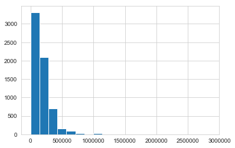

```python
plt.hist(test_income_df['v2a1'],bins=20)
plt.show()
```

```python
test_income_df.groupby("rooms").v2a1.mean()
```

```
rooms
1     6.852704e+04
2     8.733435e+04
3     1.174534e+05
4     1.256990e+05
5     1.749705e+05
6     2.199611e+05
7     3.049243e+05
8     3.242098e+05
9     5.314473e+05
10    2.418600e+05
11    2.921765e+05
12    2.852700e+06
13    1.026971e+06
14             NaN
15             NaN
Name: v2a1, dtype: float64
```

```python
def rent_payment(cols):
    rent_amount = cols[0]
    no_of_rooms = cols[1]

    if pd.isnull(rent_amount):
        if no_of_rooms == 1:
            return 6.852704e+04
        elif no_of_rooms == 2:
            return 8.733435e+04
        elif no_of_rooms == 3:
            return 1.174534e+05
        elif no_of_rooms == 4:
            return 1.256990e+05
        elif no_of_rooms == 5:
            return 1.749705e+05
        elif no_of_rooms == 6:
            return 2.199611e+05
        elif no_of_rooms == 7:
            return 3.049243e+05
        elif no_of_rooms == 8:
            return 3.242098e+05
        elif no_of_rooms == 9:
            return 5.314473e+05
        elif no_of_rooms == 10:
            return 2.418600e+05
        elif no_of_rooms == 11:
            return 2.921765e+05
        elif no_of_rooms == 12:
            return 2.852700e+06
        elif no_of_rooms == 13:
            return 1.026971e+06
        else:
            np.nan
```

```python
test_income_df['v2a1'] = test_income_df[['v2a1','rooms']].apply(rent_payment,axis=1)
```

```python
test_income_df['v2a1'].isnull().sum()
```

```
6471
```

```python
test_income_df[['v2a1']].info()
```

```
<class 'pandas.core.frame.DataFrame'>
RangeIndex: 23856 entries, 0 to 23855
Data columns (total 1 columns):
v2a1    17385 non-null float64
dtypes: float64(1)
memory usage: 186.5 KB
```

```python
imputer_test_v2a1 = Imputer(missing_values='NaN',strategy='mean')
```

```python
test_income_df['v2a1'] = imputer_test_v2a1.fit_transform(test_income_df[['v2a1']])
```

```python
test_income_df['v2a1'].isnull().sum()
```

```
0
```

```python
test_income_df[['v18q1']].info()
```

```
<class 'pandas.core.frame.DataFrame'>
RangeIndex: 23856 entries, 0 to 23855
Data columns (total 1 columns):
v18q1    5730 non-null float64
dtypes: float64(1)
memory usage: 186.5 KB
```

```python
test_income_df['v18q1'].value_counts()
```

```
1.0    4297
2.0    1005
3.0     318
4.0      88
5.0      18
6.0       4
Name: v18q1, dtype: int64
```

```python
imputer_test_v18q1 = Imputer(missing_values='NaN',strategy='most_frequent')
```

```python
test_income_df['v18q1'] = imputer_test_v18q1.fit_transform(test_income_df[['v18q1']])
```

```python
test_income_df['v18q1'].isnull().sum()
```

```
0
```

```python
test_income_df[['rez_esc']].info()
```

```
<class 'pandas.core.frame.DataFrame'>
RangeIndex: 23856 entries, 0 to 23855
Data columns (total 1 columns):
rez_esc    4203 non-null float64
dtypes: float64(1)
memory usage: 186.5 KB
```

```python
test_income_df['rez_esc'].value_counts()
```

```
0.0     3263
1.0      501
2.0      238
3.0      119
4.0       51
5.0       30
99.0       1
Name: rez_esc, dtype: int64
```

```python
imputer_res_esc_test = Imputer(missing_values='NaN',strategy='most_frequent')
imputer_res_esc_test
```

```
Imputer(axis=0, copy=True, missing_values='NaN', strategy='most_frequent',
    verbose=0)
```

```python
test_income_df['rez_esc'] = imputer_res_esc_test.fit_transform(test_income_df[['rez_esc']])
```

```python
test_income_df['rez_esc'].isnull().sum()
```

```
0
```

```python
test_income_df[['meaneduc']].info()
```

```
<class 'pandas.core.frame.DataFrame'>
RangeIndex: 23856 entries, 0 to 23855
Data columns (total 1 columns):
meaneduc    23825 non-null float64
dtypes: float64(1)
memory usage: 186.5 KB
```

```python
test_income_df.dropna(axis=0,inplace=True)
```

```python
test_income_df.reset_index(drop=True,inplace=True)
```

```python
test_income_df.shape
```

```
(23825, 140)
```

```python
#Treatment for Categorial Columns:
test_income_df['dependency'] = np.where(test_income_df['dependency']=='yes',1,test_income_df['dependency'])
test_income_df['dependency'] = np.where(test_income_df['dependency']=='no',0,test_income_df['dependency'])
test_income_df['edjefe'] = np.where(test_income_df['edjefe']=='yes',1,test_income_df['edjefe'])
test_income_df['edjefe'] = np.where(test_income_df['edjefe']=='no',0,test_income_df['edjefe'])
test_income_df['edjefa'] = np.where(test_income_df['edjefa']=='yes',1,test_income_df['edjefa'])
test_income_df['edjefa'] = np.where(test_income_df['edjefa']=='no',0,test_income_df['edjefa'])
```

```python
#Changing data type of categorial columns into numerical:
test_income_df['dependency'] = test_income_df['dependency'].astype('float')
test_income_df['edjefe'] = test_income_df['edjefe'].astype('float')
test_income_df['edjefa'] = test_income_df['edjefa'].astype('float')
```

```python
test_income_df.info()
```

```
<class 'pandas.core.frame.DataFrame'>
RangeIndex: 23825 entries, 0 to 23824
Columns: 140 entries, v2a1 to agesq
dtypes: float64(11), int64(129)
memory usage: 25.4 MB
```

- NORMALIZE THE DATASET:

```python
test_income_df.info()
```

```
<class 'pandas.core.frame.DataFrame'>
RangeIndex: 23825 entries, 0 to 23824
Columns: 140 entries, v2a1 to agesq
dtypes: float64(11), int64(129)
memory usage: 25.4 MB
```

```python
X = test_income_df.iloc[:,:].values
```

```python
X.shape
```

```
(23825, 140)
```

```python
#Create an Instance of Min-Max-Scalar:
test_min_max_sclr = MinMaxScaler()
```

```python
#Fit and Transform the Data:
X_norm_test_data = test_min_max_sclr.fit_transform(X)
```

```python
X_norm_test_df = pd.DataFrame(data=X_norm_test_data,columns=test_income_df.columns)
```

```python
#Print new datframe:
X_norm_test_df.head(10)
```

|  | v2a1 | hacdor | rooms | hacapo | v14a | refrig | v18q | v18q1 | r4h1 | r4h2 | ... | age | SQBescolari | SQBage | SQBhogar_total | SQBedjefe | SQBhogar_nin | SQBovercrowding | SQBdependency | SQBmeaned | agesq |
| --- | --- | --- | --- | --- | --- | --- | --- | --- | --- | --- | --- | --- | --- | --- | --- | --- | --- | --- | --- | --- | --- |
| 0 | 0.038232 | 0.0 | 0.285714 | 0.0 | 1.0 | 1.0 | 0.0 | 0.0 | 0.166667 | 0.142857 | ... | 0.041237 | 0.000000 | 0.001700 | 0.047619 | 0.000000 | 0.01 | 0.013194 | 0.003906 | 0.210069 | 0.001700 |
| 1 | 0.038232 | 0.0 | 0.285714 | 0.0 | 1.0 | 1.0 | 0.0 | 0.0 | 0.166667 | 0.142857 | ... | 0.422680 | 0.580499 | 0.178659 | 0.047619 | 0.000000 | 0.01 | 0.013194 | 0.003906 | 0.210069 | 0.178659 |
| 2 | 0.038232 | 0.0 | 0.285714 | 0.0 | 1.0 | 1.0 | 0.0 | 0.0 | 0.166667 | 0.142857 | ... | 0.422680 | 0.655329 | 0.178659 | 0.047619 | 0.000000 | 0.01 | 0.013194 | 0.003906 | 0.210069 | 0.178659 |
| 3 | 0.042803 | 0.0 | 0.928571 | 0.0 | 1.0 | 1.0 | 1.0 | 0.0 | 0.000000 | 0.142857 | ... | 0.608247 | 0.580499 | 0.369965 | 0.000000 | 0.580499 | 0.00 | 0.005797 | 0.000000 | 0.197531 | 0.369965 |
| 4 | 0.042803 | 0.0 | 0.142857 | 0.0 | 1.0 | 1.0 | 1.0 | 0.0 | 0.000000 | 0.000000 | ... | 0.391753 | 0.580499 | 0.153470 | 0.017857 | 0.000000 | 0.00 | 0.005797 | 0.000000 | 0.140625 | 0.153470 |
| 5 | 0.042803 | 0.0 | 0.142857 | 0.0 | 1.0 | 1.0 | 1.0 | 0.0 | 0.000000 | 0.000000 | ... | 0.432990 | 0.274376 | 0.187480 | 0.017857 | 0.000000 | 0.00 | 0.005797 | 0.000000 | 0.140625 | 0.187480 |
| 6 | 0.042803 | 0.0 | 0.357143 | 0.0 | 1.0 | 1.0 | 1.0 | 0.0 | 0.000000 | 0.000000 | ... | 0.216495 | 0.444444 | 0.046870 | 0.017857 | 0.000000 | 0.00 | 0.001359 | 0.000000 | 0.151235 | 0.046870 |
| 7 | 0.042803 | 0.0 | 0.357143 | 0.0 | 1.0 | 1.0 | 1.0 | 0.0 | 0.000000 | 0.000000 | ... | 0.226804 | 0.444444 | 0.051440 | 0.017857 | 0.000000 | 0.00 | 0.001359 | 0.000000 | 0.151235 | 0.051440 |
| 8 | 0.054391 | 0.0 | 0.357143 | 0.0 | 1.0 | 1.0 | 0.0 | 0.0 | 0.000000 | 0.000000 | ... | 0.721649 | 0.226757 | 0.520778 | 0.000000 | 0.000000 | 0.00 | 0.000537 | 1.000000 | 0.077160 | 0.520778 |
| 9 | 0.042803 | 0.0 | 0.285714 | 0.0 | 1.0 | 1.0 | 0.0 | 0.0 | 0.000000 | 0.142857 | ... | 0.185567 | 0.226757 | 0.034435 | 0.047619 | 0.000000 | 0.01 | 0.005797 | 0.003906 | 0.222994 | 0.034435 |

10 rows × 140 columns

```python
X_norm_test_sample = X_norm_test_df.iloc[2866:5732,:].values
```

```python
type(X_norm_test_sample)
```

```
numpy.ndarray
```

```python
X_norm_test_sample.shape
```

```
(2866, 140)
```

```python
#Prediction using Random Forrest with criterian='gini'
random_forrest_gini
```

```
RandomForestClassifier(bootstrap=True, class_weight=None, criterion='gini',
            max_depth=None, max_features='auto', max_leaf_nodes=None,
            min_impurity_decrease=0.0, min_impurity_split=None,
            min_samples_leaf=1, min_samples_split=2,
            min_weight_fraction_leaf=0.0, n_estimators=10, n_jobs=None,
            oob_score=False, random_state=None, verbose=0,
            warm_start=False)
```

```python
#Prediction on test dataset:
y_predict_gini =random_forrest_gini.predict(X_norm_test_sample)
```

```python
#Check Accuracy:
accuracy_with_gini = accuracy_score(y_test,y_predict_gini)
```

```python
accuracy_with_gini
```

```
0.5383810188415911
```

```python
#Random forrest with criterian='entropy'
random_forrest_entropy
```

```
RandomForestClassifier(bootstrap=True, class_weight=None, criterion='entropy',
            max_depth=None, max_features='auto', max_leaf_nodes=None,
            min_impurity_decrease=0.0, min_impurity_split=None,
            min_samples_leaf=1, min_samples_split=2,
            min_weight_fraction_leaf=0.0, n_estimators=10, n_jobs=None,
            oob_score=False, random_state=None, verbose=0,
            warm_start=False)
```

```python
y_predict_entropy = random_forrest_entropy.predict(X_norm_test_sample)
```

```python
accuracy_with_entropy = accuracy_score(y_test,y_predict_entropy)
```

```python
accuracy_with_entropy
```

```
0.5422191207257502
```

### BY OBSERVING THE ACCURACY ON TEST DATASET WE CAN CLEARLY SAY THAT *OUR MODEL IS OVERFITTED*. THIS IS BECAUSE WE HAVE TRAINED OUR MODEL OVER *ALL THE FEATURES*. SO TO MINIMIZE THIS OVERFITTING WE NEED TO USE *FEATURE ENGINNERING TECHNIQUE* WHICH DESCRIBE BELOW:

### FEATURE ENGINNERING(PCA):

```python
#Importing PCA module from sklearn:
from sklearn.decomposition import PCA
```

```python
#Make in instance:
pca = PCA(n_components=.95)
```

```python
#Fitting the dataframe:
X_train_norm_pca = pca.fit_transform(X_train_norm)
```

```python
pca.n_components_
```

```
52
```

```python
var_ratio = pca.explained_variance_ratio_
```

```python
var_ratio
```

```
array([0.13118917, 0.06441389, 0.06005077, 0.05202986, 0.04262845,
       0.03996452, 0.0338773 , 0.02957912, 0.02833399, 0.02655914,
       0.02561583, 0.02443618, 0.02070828, 0.01988448, 0.01925091,
       0.01818098, 0.01731052, 0.01678487, 0.01675194, 0.01481314,
       0.01452371, 0.01442172, 0.01355608, 0.01324958, 0.01227479,
       0.01145378, 0.0111874 , 0.01058673, 0.00979077, 0.00930118,
       0.00908555, 0.00856105, 0.00841149, 0.00777771, 0.00761589,
       0.00729094, 0.0069931 , 0.00679973, 0.00621695, 0.00611453,
       0.00598793, 0.0056136 , 0.00533239, 0.00504963, 0.0047558 ,
       0.00428089, 0.00407395, 0.00400824, 0.00392091, 0.00366197,
       0.00357198, 0.00326267])
```

```python
type(X_train_norm_pca)
```

```
numpy.ndarray
```

```python
X_train_norm_pca.shape
```

```
(9552, 52)
```

```python
X_train_pca_df = pd.DataFrame(data=X_train_norm_pca)
```

```python
X_train_pca_df.shape
```

```
(9552, 52)
```

```python
type(X_train_pca_df)
```

```
pandas.core.frame.DataFrame
```

```python
#Adding Target column to the dataframe:
X_train_final_pca_df = pd.concat([X_train_pca_df,income_train_df[['Target']]],axis=1)
```

```python
X_train_final_pca_df.shape
```

```
(9552, 53)
```

```python
X_train_final_pca_df.head()
```

|  | 0 | 1 | 2 | 3 | 4 | 5 | 6 | 7 | 8 | 9 | ... | 43 | 44 | 45 | 46 | 47 | 48 | 49 | 50 | 51 | Target |
| --- | --- | --- | --- | --- | --- | --- | --- | --- | --- | --- | --- | --- | --- | --- | --- | --- | --- | --- | --- | --- | --- |
| 0 | 0.234726 | -0.785842 | 0.912842 | 1.032392 | 1.076434 | -0.956505 | -0.315071 | -0.340301 | 1.176482 | 0.143927 | ... | -0.053293 | 0.116529 | -0.370701 | -0.039951 | 1.386616 | -0.321531 | -0.145301 | 0.032134 | -0.038353 | 4 |
| 1 | 0.455550 | -1.340442 | 1.679817 | 1.305390 | 0.434439 | 0.193691 | 0.483728 | -0.738731 | 0.998849 | 0.277311 | ... | -0.415000 | 0.025199 | -0.192946 | -0.300180 | 0.132510 | 0.422839 | -0.049370 | -0.053080 | -0.269085 | 4 |
| 2 | -0.674811 | -0.281334 | 1.635989 | -0.070384 | 0.179784 | 0.793013 | -0.505678 | 0.233122 | 0.804371 | 1.403122 | ... | 0.171301 | -0.175954 | 0.506181 | -0.314815 | 0.350492 | 0.100291 | -0.185671 | 0.142754 | 0.156078 | 4 |
| 3 | -1.449900 | -1.134793 | -0.876209 | 0.643920 | 0.382048 | 0.092611 | 0.170857 | -0.643030 | 0.826772 | -0.436886 | ... | 0.046450 | -0.077302 | -0.042432 | -0.100575 | -0.039287 | -0.013400 | -0.008610 | 0.026322 | -0.025113 | 4 |
| 4 | -1.577121 | -0.499937 | 0.593385 | -0.815568 | 0.627338 | -0.011902 | 0.592815 | -0.416232 | 0.722731 | -0.712595 | ... | 0.006159 | -0.102260 | -0.011550 | -0.062691 | -0.068282 | -0.041605 | 0.000601 | 0.025245 | -0.012840 | 4 |

5 rows × 53 columns

```python
#Seperate features and columns:
X = X_train_final_pca_df.iloc[:,:52].values
y = X_train_final_pca_df.iloc[:,52].values
```

```python
X.shape
```

```
(9552, 52)
```

```python
y.shape
```

```
(9552,)
```

```python
#Spliting the dataset into train and test:
X_train_pca,X_test_pca,y_train_pca,y_test_pca = train_test_split(X,y,test_size=.3,random_state=22)
```

```python
print('X_train_pca',X_train_pca.shape)
print('X_test_pca',X_test_pca.shape)
print('y_train_pca',y_train_pca.shape)
print('y_test_pca',y_test_pca.shape)
```

```
X_train_pca (6686, 52)
X_test_pca (2866, 52)
y_train_pca (6686,)
y_test_pca (2866,)
```

- BUILDING THE MODEL:

```python
random_forrest_pca_gini = RandomForestClassifier()
random_forrest_pca_gini
```

```
RandomForestClassifier(bootstrap=True, class_weight=None, criterion='gini',
            max_depth=None, max_features='auto', max_leaf_nodes=None,
            min_impurity_decrease=0.0, min_impurity_split=None,
            min_samples_leaf=1, min_samples_split=2,
            min_weight_fraction_leaf=0.0, n_estimators='warn', n_jobs=None,
            oob_score=False, random_state=None, verbose=0,
            warm_start=False)
```

```python
#Fit the data:
random_forrest_pca_gini.fit(X_train_pca,y_train_pca)
```

```
RandomForestClassifier(bootstrap=True, class_weight=None, criterion='gini',
            max_depth=None, max_features='auto', max_leaf_nodes=None,
            min_impurity_decrease=0.0, min_impurity_split=None,
            min_samples_leaf=1, min_samples_split=2,
            min_weight_fraction_leaf=0.0, n_estimators=10, n_jobs=None,
            oob_score=False, random_state=None, verbose=0,
            warm_start=False)
```

```python
#Predict using Evaluation data:
y_predict_gini_pca = random_forrest_pca_gini.predict(X_test_pca)
```

```python
#Check Accuracy score:
accuracy_gini_pca = accuracy_score(y_test_pca,y_predict_gini_pca)
```

```python
print("Accuracy using PCA(gini):",accuracy_gini_pca)
```

```
Accuracy using PCA(gini): 0.7271458478715981
```

- Using **criterian = 'entropy':**

```python
random_forrest_pca_entropy = RandomForestClassifier(criterion='entropy')
random_forrest_pca_entropy
```

```
RandomForestClassifier(bootstrap=True, class_weight=None, criterion='entropy',
            max_depth=None, max_features='auto', max_leaf_nodes=None,
            min_impurity_decrease=0.0, min_impurity_split=None,
            min_samples_leaf=1, min_samples_split=2,
            min_weight_fraction_leaf=0.0, n_estimators='warn', n_jobs=None,
            oob_score=False, random_state=None, verbose=0,
            warm_start=False)
```

```python
#Fit the data:
random_forrest_pca_entropy.fit(X_train_pca,y_train_pca)
```

```
RandomForestClassifier(bootstrap=True, class_weight=None, criterion='entropy',
            max_depth=None, max_features='auto', max_leaf_nodes=None,
            min_impurity_decrease=0.0, min_impurity_split=None,
            min_samples_leaf=1, min_samples_split=2,
            min_weight_fraction_leaf=0.0, n_estimators=10, n_jobs=None,
            oob_score=False, random_state=None, verbose=0,
            warm_start=False)
```

```python
#Predict using Evaluation data:
y_predict_entropy_pca = random_forrest_pca_entropy.predict(X_test_pca)
```

```python
#Check Accuracy:
accuracy_entropy_pca = accuracy_score(y_test_pca,y_predict_entropy_pca)
```

```python
print('Accuracy using PCA(entropy):',accuracy_entropy_pca)
```

```
Accuracy using PCA(entropy): 0.7274947662247034
```

```python
print(classification_report(y_test_pca,y_predict_entropy_pca))
```

```
              precision    recall  f1-score   support

           1       0.75      0.40      0.52       246
           2       0.56      0.48      0.52       478
           3       0.68      0.31      0.42       376
           4       0.76      0.93      0.84      1766

   micro avg       0.73      0.73      0.73      2866
   macro avg       0.69      0.53      0.58      2866
weighted avg       0.72      0.73      0.70      2866
```

```python
confusion_matrix(y_test_pca,y_predict_entropy_pca)
```

```
array([[  99,   43,    6,   98],
       [  14,  231,   15,  218],
       [  11,   56,  115,  194],
       [   8,   86,   32, 1640]], dtype=int64)
```

### TESTING MODEL ON TEST DATA:

```python
#Feature Reduction:
test_pca = PCA(n_components=52)
```

```python
X_norm_test_data.shape
```

```
(23825, 140)
```

```python
#Transform the data:
X_norm_test_pca = test_pca.fit_transform(X_norm_test_data)
```

```python
X_norm_test_pca_df = pd.DataFrame(data=X_norm_test_pca)
```

```python
X_norm_test_pca_df.shape
```

```
(23825, 52)
```

```python
#Print the dataframe:
X_norm_test_pca_df.head()
```

|  | 0 | 1 | 2 | 3 | 4 | 5 | 6 | 7 | 8 | 9 | ... | 42 | 43 | 44 | 45 | 46 | 47 | 48 | 49 | 50 | 51 |
| --- | --- | --- | --- | --- | --- | --- | --- | --- | --- | --- | --- | --- | --- | --- | --- | --- | --- | --- | --- | --- | --- |
| 0 | -0.929653 | -0.247715 | -1.104456 | 0.355939 | -0.035174 | -0.900444 | 0.054967 | -0.118034 | 1.481139 | 0.546441 | ... | -0.080966 | 0.077799 | -0.003314 | 0.037477 | -0.148755 | -0.026979 | -0.037599 | 0.065422 | 0.040654 | 0.161432 |
| 1 | -1.396981 | 0.213387 | 0.375035 | 0.435619 | -0.282137 | -0.807504 | -0.644483 | -0.416575 | 0.766567 | 0.163957 | ... | -0.082475 | 0.090114 | -0.004574 | 0.052494 | -0.073589 | -0.160093 | -0.024392 | 0.016982 | 0.040281 | 0.278521 |
| 2 | -1.347050 | 0.300454 | 0.766440 | -0.343742 | -0.128352 | -0.796214 | -0.856371 | -0.545306 | 0.712204 | 0.061301 | ... | -0.060705 | 0.021700 | 0.004228 | 0.043971 | -0.134152 | -0.129509 | 0.023829 | -0.002167 | 0.081974 | 0.211264 |
| 3 | -1.880977 | -0.282132 | 0.522075 | 1.058077 | 0.417142 | 0.045120 | -0.332655 | -0.783886 | 0.306933 | 0.011794 | ... | -0.037687 | 0.300227 | -0.046055 | 0.075992 | -0.326834 | -0.103175 | -0.027150 | 0.066532 | -0.000487 | 0.138666 |
| 4 | -0.481739 | -1.651506 | 0.531219 | -0.622363 | -0.005920 | 0.283698 | -0.163838 | -1.257303 | -0.182231 | -0.515916 | ... | 0.827579 | 0.232428 | 0.516544 | -0.027841 | -0.112625 | 0.036350 | -0.121313 | 0.068187 | -0.194819 | 0.075220 |

5 rows × 52 columns

```python
X_norm_test_sample_pca = X_norm_test_pca_df.iloc[:2866,:].values
```

```python
X_norm_test_sample_pca.shape
```

```
(2866, 52)
```

```python
#Prediction on Test Data:
y_predict_test_pca_gini = random_forrest_pca_gini.predict(X_norm_test_sample_pca)
```

```python
#Check Accuracy:
accuracy_on_test_pca_gini = accuracy_score(y_test_pca,y_predict_test_pca_gini)
```

```python
accuracy_on_test_pca_gini
```

```
0.5526866713189114
```

```python
y_predict_test_pca_entropy = random_forrest_pca_entropy.predict(X_norm_test_sample_pca)
```

```python
accuracy_on_test_pca_entropy = accuracy_score(y_test_pca,y_predict_test_pca_entropy)
```

```python
accuracy_on_test_pca_entropy
```

```
0.5540823447313329
```

```python
print(classification_report(y_test_pca,y_predict_test_pca_entropy))
```

```
              precision    recall  f1-score   support

           1       0.15      0.03      0.05       246
           2       0.14      0.06      0.08       478
           3       0.04      0.01      0.02       376
           4       0.62      0.88      0.72      1766

   micro avg       0.55      0.55      0.55      2866
   macro avg       0.24      0.24      0.22      2866
weighted avg       0.42      0.55      0.47      2866
```

```python
confusion_matrix(y_test_pca,y_predict_test_pca_entropy)
```

```
array([[   8,   19,   15,  204],
       [   7,   29,   13,  429],
       [   7,   36,    4,  329],
       [  33,  126,   60, 1547]], dtype=int64)
```